# 市场观察

2017/06/15

## A、指数估值

### (a1)动态市盈率、市净率

核心指数成分股近18个月的动态市盈率及动态市净率中位数走势如下图所示：

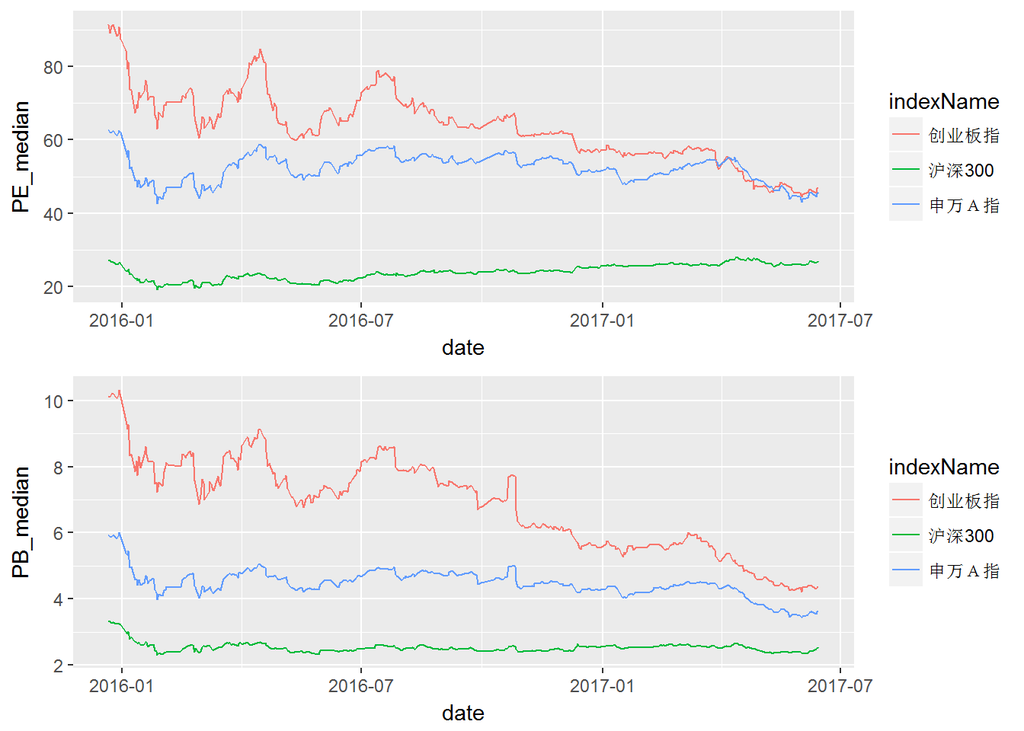

### (a2)动态市盈率、市净率百分位

核心指数近18个月的动态市盈率百分位及动态市净率百分位走势如下图所示：

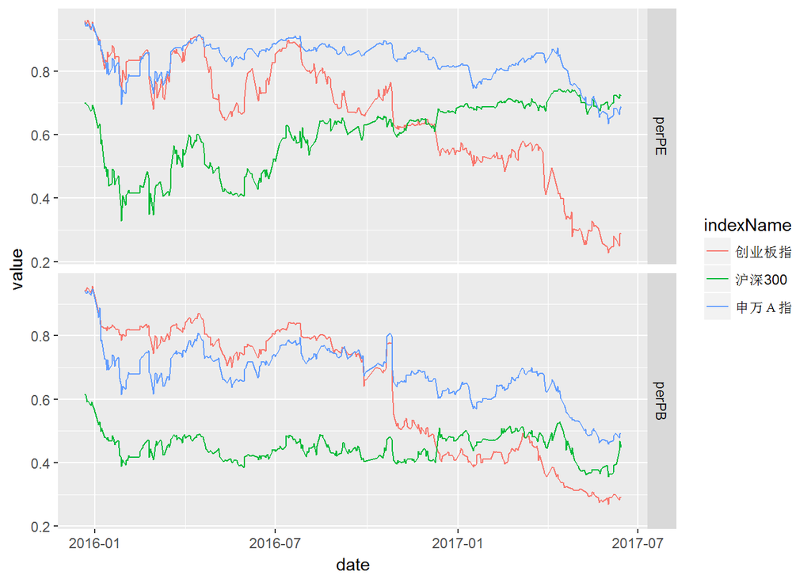

### (a3)指数估值概览

纳入观察的指数最新的估值情况如下表，根据市盈率和市净率分位数均值降序排列。

| 指数代码 | 指数简称 | 日期 | 动态市盈率 | 市盈率百分位 | 动态市净率 | 市净率百分位 |
| --- | --- | --- | --- | --- | --- | --- |
| EI801003 | 申万Ａ指 | 2017-06-14 | 45.8 | 69% | 3.6 | 49% |
| EI000300 | 沪深300 | 2017-06-14 | 26.7 | 72% | 2.5 | 45% |
| EI399330 | 深证100 | 2017-06-14 | 32.9 | 67% | 3.6 | 48% |
| EI000819 | 有色金属 | 2017-06-14 | 54.6 | 71% | 3.1 | 33% |
| EI399005 | 中小板指P | 2017-06-14 | 40.3 | 61% | 4.3 | 36% |
| EI399959 | 军工指数 | 2017-06-14 | 80.2 | 54% | 3.6 | 42% |
| EI000979 | 大宗商品 | 2017-06-14 | 30.8 | 55% | 2.5 | 39% |
| EI000905 | 中证500 | 2017-06-14 | 35.5 | 47% | 2.8 | 31% |
| EI000934 | 中证金融 | 2017-06-14 | 19.3 | 65% | 1.7 | 12% |
| EI000998 | 中证TMT | 2017-06-14 | 42.0 | 42% | 3.5 | 28% |
| EI399006 | 创业板指 | 2017-06-14 | 46.8 | 29% | 4.4 | 29% |
| EI000016 | 上证50 | 2017-06-14 | 16.1 | 45% | 1.6 | 11% |
| EI000932 | 中证消费 | 2017-06-14 | 30.2 | 35% | 3.6 | 11% |
| EI000922 | 中证红利 | 2017-06-14 | 15.4 | 23% | 1.7 | 21% |
| EI000827 | 中证环保 | 2017-06-14 | 33.9 | 19% | 2.9 | 23% |
| EI000933 | 中证医药 | 2017-06-14 | 34.0 | 28% | 3.8 | 5% |

### (a4)另类估值

我国10年期国债收益率、金银比价、金油比价，2000年以来的历史百分位如下图所示：

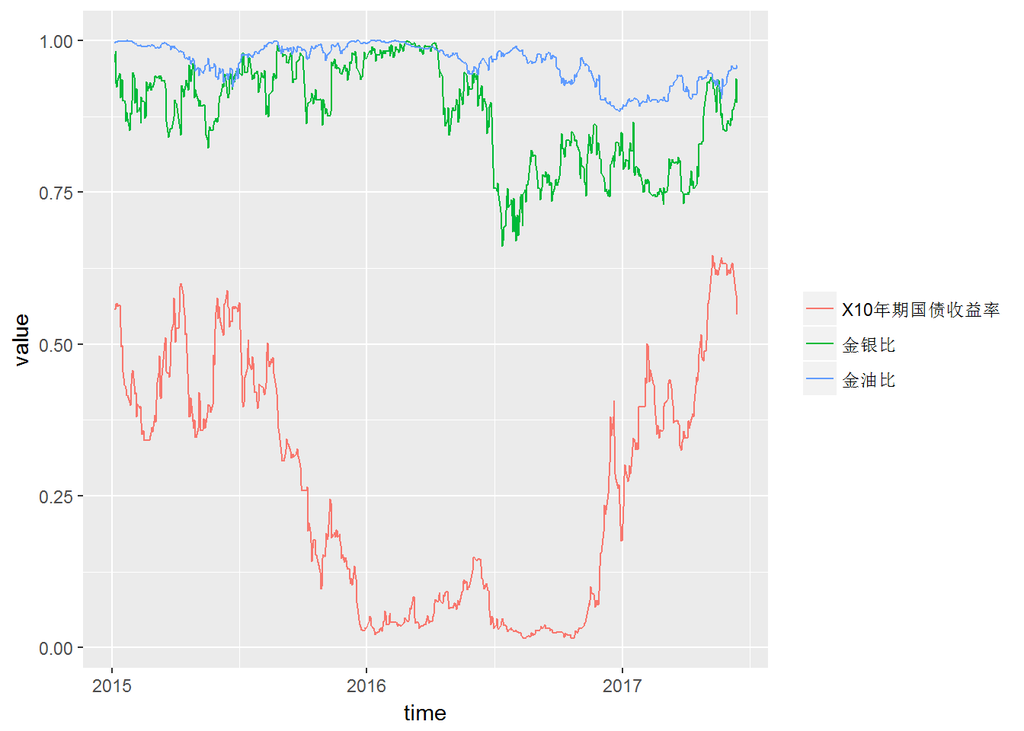

## B、基差及市场情绪

### (b1)基差走势

三大股指期货合约基差走势如下图，其中当月合约和次月合约年化基差百分比波动较大，仅展示合约基差百分比，当季合约和次季合约展示基差年化百分比：

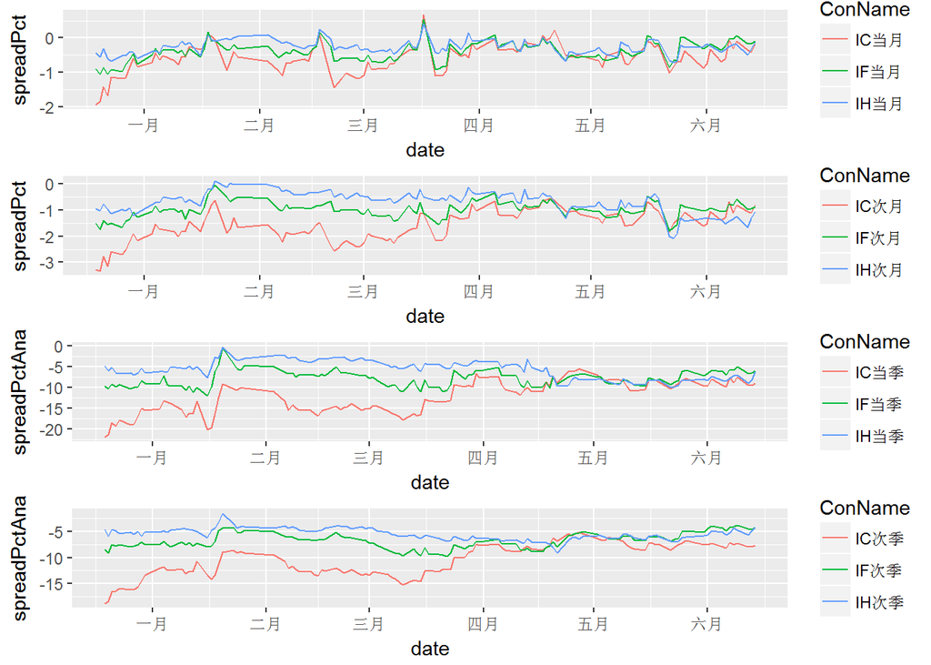

### (b2)基差概况

三大股指期货连续合约基差概况如下表，近月合约临近到期日，年化基差百分比数据波动较大：

| 日期 | 合约代码 | 合约收盘价 | 指数收盘价 | 基差 | 基差百分比 | 年化基差百分比 |
| --- | --- | --- | --- | --- | --- | --- |
| 2017-06-14 | IC1706 | 5956.6 | 5966.4 | -9.8 | -0.2% | -35.0% |
| 2017-06-14 | IC1707 | 5918.8 | 5966.4 | -47.6 | -0.8% | -8.2% |
| 2017-06-14 | IC1709 | 5832.0 | 5966.4 | -134.4 | -2.3% | -9.1% |
| 2017-06-14 | IC1712 | 5740.6 | 5966.4 | -225.8 | -3.8% | -7.6% |
| 2017-06-14 | IF1706 | 3532.0 | 3535.3 | -3.3 | -0.1% | -18.6% |
| 2017-06-14 | IF1707 | 3504.0 | 3535.3 | -31.3 | -0.9% | -9.1% |
| 2017-06-14 | IF1709 | 3482.0 | 3535.3 | -53.3 | -1.5% | -6.0% |
| 2017-06-14 | IF1712 | 3460.0 | 3535.3 | -75.3 | -2.1% | -4.3% |
| 2017-06-14 | IH1706 | 2474.8 | 2477.3 | -2.5 | -0.1% | -20.4% |
| 2017-06-14 | IH1707 | 2451.2 | 2477.3 | -26.1 | -1.1% | -10.9% |
| 2017-06-14 | IH1709 | 2438.4 | 2477.3 | -38.9 | -1.6% | -6.3% |
| 2017-06-14 | IH1712 | 2425.6 | 2477.3 | -51.7 | -2.1% | -4.2% |

### (b3)市场情绪(provided by han.qian)

市场情绪记录近60天每天自然涨跌停(剔除一字板)、创60日新高新低、多头排列空头排列(均线组合5,30,60,120)的股票数。

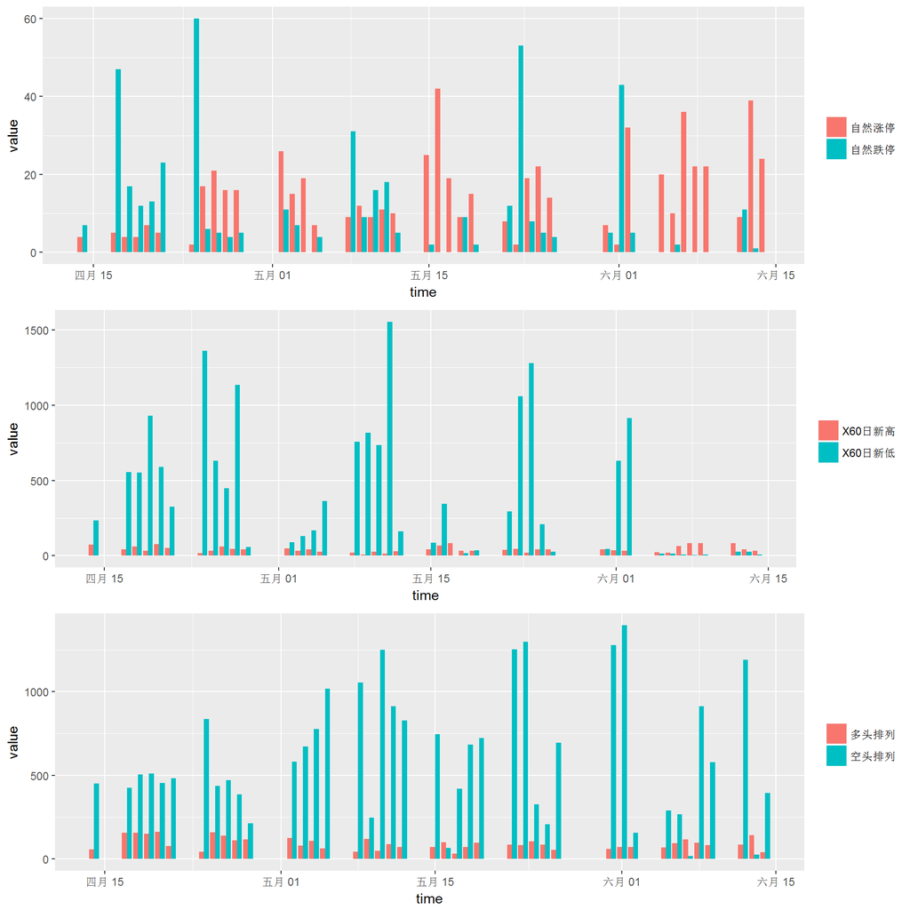

## C、套利和事件

### (c1)复牌股票套利

近两天复牌股票套利情况如下表：

[1] “No Arbitrage!”

### (c2)定增基金(provided by han.qian)

定增基金数据如下表，明细数据参见钱瀚的模板。

| 代码 | 名称 | 到期日期 | 最新净值 | 昨日收盘价 | 折溢价率 | 整体隐含折价率 | 大盘下跌0.1净值变化 |
| --- | --- | --- | --- | --- | --- | --- | --- |
| 168101.OF | 九泰锐智 | 20200814 | 1.13 | 0.92 | -18.6% | 4.1% | -10.2% |
| 168102.OF | 九泰锐富 | 20210204 | 0.98 | 0.77 | -21.4% | 2.5% | -5.7% |
| 501015.OF | 财通升级 | 20170908 | 0.97 | 0.90 | -6.4% | 0.6% | -9.2% |
| 160518.OF | 博时睿远 | 20171016 | 0.95 | 0.88 | -7.5% | 0.6% | -6.8% |

定增基金近期的净值走势如下图：

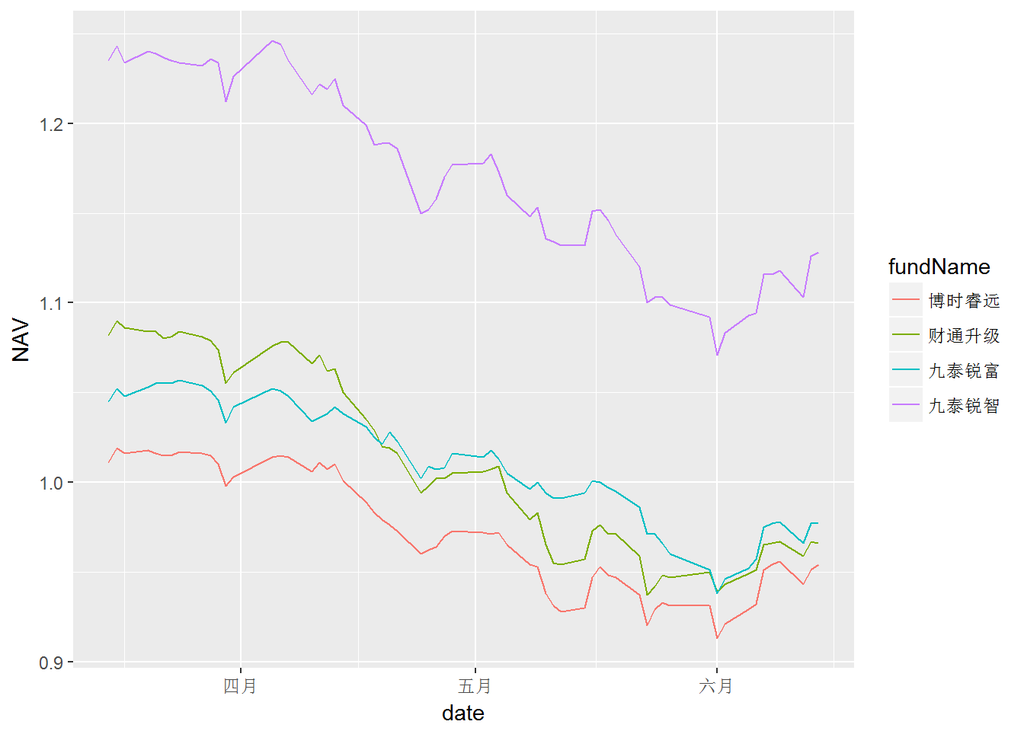

定增基金近期的折溢价率百分比走势如下图：

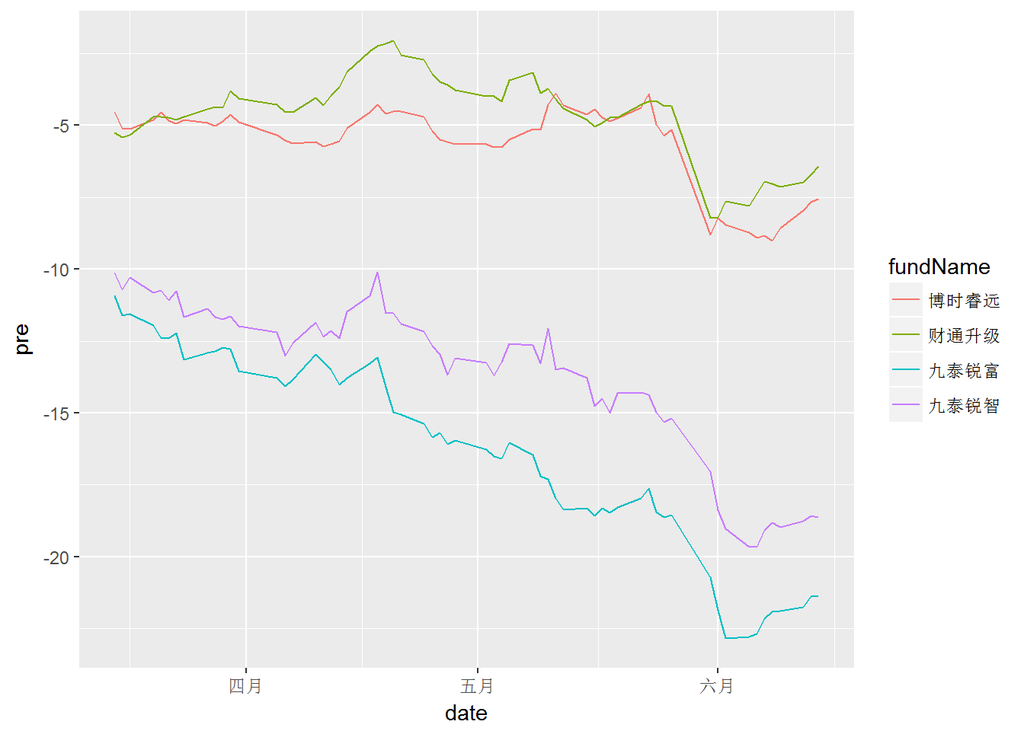

### (c3)解禁

解禁分成两个部分，定增解禁和IPO解禁，涨跌幅记录是过去十个交易日的股票涨跌幅和对应行业指数涨跌幅。伴随着去年下半年IPO逐步正常化，今后IPO解禁给市场造成的抛压会持续存在，所以纳入观察。近期定增解禁的股票情况如下表。

| 股票代码 | 股票简称 | 解禁日 | 解禁数量 | 解禁百分比 | 区间涨跌幅 | 所属行业指数 | 行业指数涨跌幅 |
| --- | --- | --- | --- | --- | --- | --- | --- |
| EQ000547 | 航天发展 | 2017-06-16 | 1.14 | 13% | 6.8% | 申万通信 | 1.6% |
| EQ603118 | 共进股份 | 2017-06-19 | 1.02 | 38% | -3.2% | 申万通信 | 1.6% |
| EQ002200 | 云投生态 | 2017-06-19 | 0.33 | 31% | 5.3% | 申万建筑装饰 | 1.8% |
| EQ002005 | 德豪润达 | 2017-06-19 | 2.30 | 20% | 6.5% | 申万电子 | 2.4% |
| EQ000530 | 大冷股份 | 2017-06-20 | 0.82 | 16% | 5.2% | 申万机械设备 | 0.8% |
| EQ600807 | 天业股份 | 2017-06-20 | 2.11 | 32% | 3.1% | 申万房地产 | 0.7% |
| EQ002021 | 中捷资源 | 2017-06-20 | 1.20 | 21% | -0.3% | 申万机械设备 | 0.8% |
| EQ300031 | 宝通科技 | 2017-06-20 | 0.29 | 13% | 2.7% | 申万化工 | 1.8% |
| EQ000885 | 同力水泥 | 2017-06-20 | 0.48 | 11% | 0.0% | 申万建筑材料 | 2.2% |
| EQ002277 | 友阿股份 | 2017-06-20 | 2.84 | 25% | 1.0% | 申万商业贸易 | 1.6% |
| EQ002683 | 宏大爆破 | 2017-06-21 | 0.53 | 11% | 0.8% | 申万化工 | 1.8% |
| EQ002026 | 山东威达 | 2017-06-23 | 0.38 | 11% | -0.4% | 申万机械设备 | 0.8% |
| EQ002600 | 江粉磁材 | 2017-06-23 | 1.31 | 26% | 0.0% | 申万有色金属 | 3.3% |
| EQ300317 | 珈伟股份 | 2017-06-26 | 0.96 | 41% | 11.0% | 申万电子 | 2.4% |
| EQ300021 | 大禹节水 | 2017-06-26 | 1.01 | 24% | 7.9% | 申万农林牧渔 | 1.2% |
| EQ002223 | 鱼跃医疗 | 2017-06-26 | 1.14 | 15% | 4.2% | 申万医药生物 | 2.2% |
| EQ002077 | 大港股份 | 2017-06-26 | 0.76 | 26% | 8.1% | 申万房地产 | 0.7% |
| EQ002432 | 九安医疗 | 2017-06-27 | 0.61 | 16% | 6.2% | 申万医药生物 | 2.2% |
| EQ000591 | 太阳能 | 2017-06-28 | 8.05 | 77% | -3.7% | 申万电气设备 | 2.1% |
| EQ600438 | 通威股份 | 2017-06-28 | 3.50 | 18% | 3.2% | 申万农林牧渔 | 1.2% |
| EQ603019 | 中科曙光 | 2017-06-28 | 0.43 | 12% | -2.7% | 申万计算机 | 2.1% |
| EQ600376 | 首开股份 | 2017-06-28 | 3.04 | 14% | -2.1% | 申万房地产 | 0.7% |
| EQ603009 | 北特科技 | 2017-06-29 | 0.18 | 50% | 18.3% | 申万汽车 | 4.0% |

近期IPO解禁的股票情况如下表。

| 股票代码 | 股票简称 | 解禁日 | 解禁数量 | 解禁百分比 | 区间涨跌幅 | 所属行业指数 | 行业指数涨跌幅 | 上市日 |
| --- | --- | --- | --- | --- | --- | --- | --- | --- |
| EQ300516 | 久之洋 | 2017-06-02 | 0.05 | 17% | 7.2% | 申万电子 | 2.4% | 2016-06-02 |
| EQ300513 | 恒泰实达 | 2017-06-02 | 0.18 | 94% | 10.2% | 申万计算机 | 2.1% | 2016-05-30 |
| EQ603737 | 三棵树 | 2017-06-05 | 0.05 | 21% | -2.2% | 申万化工 | 1.8% | 2016-06-03 |
| EQ300370 | 安控科技 | 2017-06-06 | 0.56 | 11% | 10.7% | 申万电气设备 | 2.1% | 2014-01-23 |
| EQ002799 | 环球印务 | 2017-06-08 | 0.26 | 105% | 10.1% | 申万轻工制造 | 2.1% | 2016-06-08 |
| EQ300515 | 三德科技 | 2017-06-08 | 0.19 | 77% | 22.0% | 申万机械设备 | 0.8% | 2016-06-08 |
| EQ601611 | 中国核建 | 2017-06-12 | 4.37 | 83% | -1.5% | 申万建筑装饰 | 1.8% | 2016-06-06 |
| EQ300475 | 聚隆科技 | 2017-06-12 | 0.11 | 18% | 12.3% | 申万家用电器 | 4.8% | 2015-06-10 |
| EQ601127 | 小康股份 | 2017-06-15 | 0.38 | 26% | 7.2% | 申万汽车 | 4.0% | 2016-06-15 |
| EQ300519 | 新光药业 | 2017-06-26 | 0.29 | 147% | 5.1% | 申万医药生物 | 2.2% | 2016-06-24 |
| EQ300518 | 盛讯达 | 2017-06-26 | 0.23 | 100% | 0.0% | 申万传媒 | 2.4% | 2016-06-24 |
| EQ300385 | 雪浪环境 | 2017-06-26 | 0.72 | 150% | 5.5% | 申万机械设备 | 0.8% | 2014-06-26 |
| EQ300386 | 飞天诚信 | 2017-06-26 | 1.38 | 81% | 10.1% | 申万计算机 | 2.1% | 2014-06-26 |
| EQ002726 | 龙大肉食 | 2017-06-26 | 3.27 | 301% | 2.1% | 申万食品饮料 | 5.9% | 2014-06-26 |
| EQ603958 | 哈森股份 | 2017-06-29 | 0.12 | 21% | 5.1% | 申万纺织服装 | 1.6% | 2016-06-29 |
| EQ002802 | 洪汇新材 | 2017-06-29 | 0.13 | 48% | 6.7% | 申万化工 | 1.8% | 2016-06-29 |

### (c4)中小板业绩预增预测(provided by han.qian)

中小板规定正式财务报告发布的同时需要发布新一期的业绩预报，比如年报中会包含一季报预告的情况。我们假设公司的盈利状况有动量效应，年报预增的公司一季度也会预增，在正式财务报告发布前20个交易日开始埋伏，然后等正式报告发布日卖出。具体研究参见钱瀚前期的研究。需要注意的是这里的收益率仅做展示，仅仅是每日全部入选股票的平均收益率，并没有做成一个事件组合。

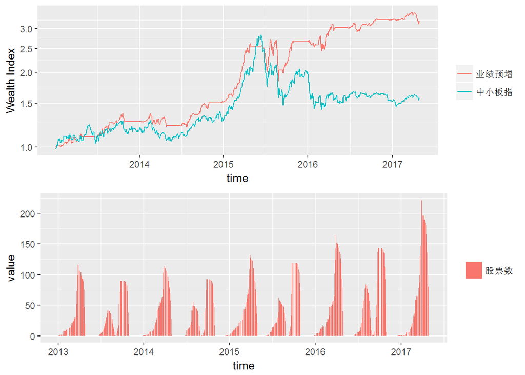

历年收益统计如下表所示。

|  | 业绩预增 | 中小板指 |
| --- | --- | --- |
| 2013-01-04 ~ 2013-12-31 | 26.4% | 17.5% |
| 2014-01-02 ~ 2014-12-31 | 20.4% | 9.7% |
| 2015-01-05 ~ 2015-12-31 | 75.9% | 53.7% |
| 2016-01-04 ~ 2016-12-30 | 22.3% | -22.9% |
| 2017-01-03 ~ 2017-04-28 | -1.0% | 2.6% |
| Cumulative Return | 224.2% | 56.7% |
| Annualized Return | 31.3% | 11.0% |